# Exploring Solutions for extracting recovery measures information from Recovery Documents using Reproducible Analytical Pipelines

Strategic RAP Champions

2022-09-13

## Project Conceptual Diagram

This document summarizes a collection of solutions for extracting recovery measures information from Recovery Documents using Reproducible Analytical Pipelines. Findings will help identify best practices for future data entry and reporting. Outcomes of this project will include:

- Testing and evaluating the use of Reproducible Analytical Pipelines to automate data extraction from SARA recovery documents and Species at Risk geodatabase.
- Make recommendations regarding document elements (e.g. formatting or codes) required to identify and extract relevant information into a spreadsheet. This will coincide with the Species at Risk Program recovery and implementation team plans to revise Species’ Progress Report templates and other recovery document templates this fiscal year.
- Conceptual workflow of elements that would be required to reverse-engineer outcomes 1 and 2 (above) by using forms, csv files, or Excel spreadsheets to generate reproducible reports (e.g. using Microsoft PowerBI, R Markdown, or other tools that are easily used and accessible to Species at Risk Program staff).

For more information about this project, please see the [project proposal.](https://086gc.sharepoint.com/:w:/s/MaritimesSpatialPlanning-MAROpenDataLogistics/EZLu-2jTNt1DgVY_0GsX3eEBtsJwi7xA_vWNSAqwBURbdg)

```r
workflow
```

[interactive chart not shown]

## Exploration of options for Step 1 to Step 2: Examples below display outcomes for Table 4 of Mud-Piddock Recovery Assessment.

Exploring solutions if tables in PDFs are the preferred way to store information

```r
Option1
```

[interactive chart not shown]

Examples below display outcomes for Table 4 of Mud-Piddock Recovery Assessment.

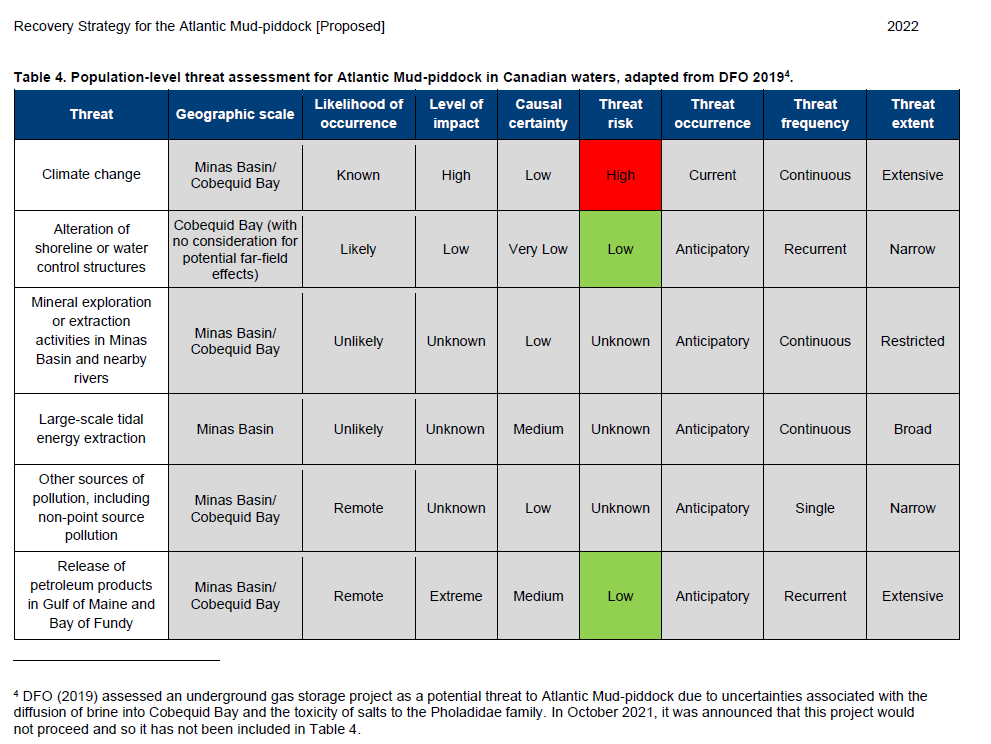

Original screenshot of table in the PDF

### `tabulizer` R Package

Package ‘tabulizer’ was removed from the CRAN repository thus installation was conducted directly from GitHub. This leaves us at the mercy of package developers that could discontinue its mantainance. More here: https://github.com/ropensci/tabulizer

```r
#remotes::install_github(c("ropensci/tabulizerjars", "ropensci/tabulizer"), INSTALL_opts = "--no-multiarch")
```

```r
library(remotes)
library(rJava)
library(tabulizer)
tabletest <- "Rs-PholadeTronqueeAtlMudPiddock-v00-2022Aug-Eng.pdf"
#fullextraction <- extract_tables(tabletest) # You may uncomment this line if you would like to extract tables form the whole document.
table4 <- extract_tables(tabletest, pages = 20)
table4
```

```
## [[1]]
##       [,1]                   [,2]                   [,3]            [,4]
##  [1,] ""                     ""                     "Likelihood of" "Level of"
##  [2,] "Threat"               "Geographic scale"     ""              ""
##  [3,] ""                     ""                     "occurrence"    "impact"
##  [4,] ""                     ""                     ""              ""
##  [5,] ""                     "Minas Basin/"         ""              ""
##  [6,] "Climate change"       ""                     "Known"         "High"
##  [7,] ""                     "Cobequid Bay"         ""              ""
##  [8,] ""                     ""                     ""              ""
##  [9,] "Alteration of"        "Cobequid Bay (with"   ""              ""
## [10,] ""                     "no consideration for" ""              ""
## [11,] "shoreline or water"   ""                     "Likely"        "Low"
## [12,] ""                     "potential far-field"  ""              ""
## [13,] "control structures"   ""                     ""              ""
```

[output cut: 56 more lines]

The output is a bit convoluted with a series of empty spaces and disjointed/unconnected text. Thus next step is to turn the table extraction into a data frame to get an output that resembles the original table a tiny bit more, yet issues prevailed and a bit more tweaking is required (coding side and/or way tables are designed = the simpler the table, the easier for the code to extract it).

```r
table4df <- extract_tables(tabletest, pages = 20, output = "data.frame") %>% as.data.frame()
table4df
```

```
##                       X                  X.1 Likelihood.of Level.of    Causal
## 1                Threat     Geographic scale
## 2                                               occurrence   impact certainty
## 3
## 4                               Minas Basin/
## 5        Climate change                              Known     High       Low
## 6                               Cobequid Bay
## 7
## 8         Alteration of   Cobequid Bay (with
## 9                       no consideration for
## 10   shoreline or water                             Likely      Low  Very Low
## 11                       potential far-field
## 12   control structures
## 13                                  effects)
## 14  Mineral exploration
## 15        or extraction
## 16                              Minas Basin/
## 17  activities in Minas                           Unlikely  Unknown       Low
## 18                              Cobequid Bay
## 19     Basin and nearby
## 20               rivers
## 21    Large-scale tidal
## 22                               Minas Basin      Unlikely  Unknown    Medium
## 23    energy extraction
## 24     Other sources of
## 25 pollution, including         Minas Basin/
## 26                                                  Remote  Unknown       Low
## 27     non-point source         Cobequid Bay
## 28            pollution
## 29           Release of
## 30   petroleum products         Minas Basin/
## 31                                                  Remote  Extreme    Medium
## 32 in Gulf of Maine and         Cobequid Bay
## 33         Bay of Fundy
##     Threat     Threat.1   Threat.2   Threat.3
## 1
## 2     risk   occurrence  frequency     extent
## 3
## 4
## 5     High      Current Continuous  Extensive
```

[output cut: 13 more lines]

```
## 19
## 20
## 21
## 22 Unknown Anticipatory Continuous      Broad
## 23
## 24
## 25
## 26 Unknown Anticipatory     Single     Narrow
## 27
## 28
## 29
## 30
## 31     Low Anticipatory  Recurrent  Extensive
## 32
## 33
```

```r
library(kableExtra)
table4df %>% kbl(caption = "Table 4") %>%
         kable_classic(full_width = F, html_font = "Cambria")
```

Table 4

| X | X.1 | Likelihood.of | Level.of | Causal | Threat | Threat.1 | Threat.2 | Threat.3 |
| --- | --- | --- | --- | --- | --- | --- | --- | --- |
| Threat | Geographic scale |  |  |  |  |  |  |  |
|  |  | occurrence | impact | certainty | risk | occurrence | frequency | extent |
|  | Minas Basin/ |  |  |  |  |  |  |  |
| Climate change |  | Known | High | Low | High | Current | Continuous | Extensive |
|  | Cobequid Bay |  |  |  |  |  |  |  |
| Alteration of | Cobequid Bay (with |  |  |  |  |  |  |  |
|  | no consideration for |  |  |  |  |  |  |  |
| shoreline or water |  | Likely | Low | Very Low | Low | Anticipatory | Recurrent | Narrow |
|  | potential far-field |  |  |  |  |  |  |  |
| control structures |  |  |  |  |  |  |  |  |
|  | effects) |  |  |  |  |  |  |  |
| Mineral exploration |  |  |  |  |  |  |  |  |
| or extraction |  |  |  |  |  |  |  |  |
|  | Minas Basin/ |  |  |  |  |  |  |  |
| activities in Minas |  | Unlikely | Unknown | Low | Unknown | Anticipatory | Continuous | Restricted |
|  | Cobequid Bay |  |  |  |  |  |  |  |
| Basin and nearby |  |  |  |  |  |  |  |  |
| rivers |  |  |  |  |  |  |  |  |
| Large-scale tidal |  |  |  |  |  |  |  |  |
|  | Minas Basin | Unlikely | Unknown | Medium | Unknown | Anticipatory | Continuous | Broad |
| energy extraction |  |  |  |  |  |  |  |  |
| Other sources of |  |  |  |  |  |  |  |  |
| pollution, including | Minas Basin/ |  |  |  |  |  |  |  |
|  |  | Remote | Unknown | Low | Unknown | Anticipatory | Single | Narrow |
| non-point source | Cobequid Bay |  |  |  |  |  |  |  |
| pollution |  |  |  |  |  |  |  |  |
| Release of |  |  |  |  |  |  |  |  |
| petroleum products | Minas Basin/ |  |  |  |  |  |  |  |
|  |  | Remote | Extreme | Medium | Low | Anticipatory | Recurrent | Extensive |
| in Gulf of Maine and | Cobequid Bay |  |  |  |  |  |  |  |
| Bay of Fundy |  |  |  |  |  |  |  |  |

*Demos*:

- https://github.com/ropensci/tabulizer
- Tabulizer Package: https://www.youtube.com/watch?v=nlsWjezvsg8
- PDF Scrape and exploratory analysis code demo: https://www.business-science.io/code-tools/2019/09/23/tabulizer-pdf-scraping.html#workflow

### `docxtractr` R Package

PDFs seem to have some tricky issues consistently observed while trying different solutions. What about Word Files? We saved Table 4 as a separate Word file and tested `docxtractr` R Package.

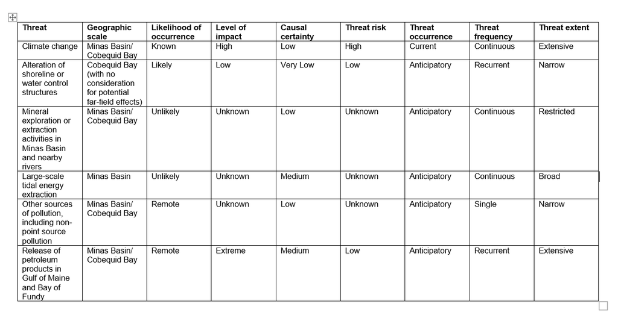

Simplified table in Word

The solution below still requires a bit more development but the simple extraction seems similar to the original table 4. Keeping tables as simple as possible in the word or PDF file is one of the main pieces to implement moving forward.

```r
library(docxtractr)
tabletestdocx <-  read_docx("table4.docx")
docx_tbl_count(tabletestdocx)
```

```
## [1] 1
```

```r
tbls <- docx_extract_all_tbls(tabletestdocx)
tbls
```

```
## [[1]]
## # A tibble: 7 × 9
##   V1                             V2    V3    V4    V5    V6    V7    V8    V9
##   <chr>                          <chr> <chr> <chr> <chr> <chr> <chr> <chr> <chr>
## 1 Threat                         Geog… Like… Leve… Caus… Thre… Thre… Thre… Thre…
## 2 Climate change                 Mina… Known High  Low   High  Curr… Cont… Exte…
## 3 Alteration of shoreline or wa… Cobe… Like… Low   Very… Low   Anti… Recu… Narr…
## 4 Mineral exploration or extrac… Mina… Unli… Unkn… Low   Unkn… Anti… Cont… Rest…
## 5 Large-scale tidal energy extr… Mina… Unli… Unkn… Medi… Unkn… Anti… Cont… Broad
## 6 Other sources of pollution, i… Mina… Remo… Unkn… Low   Unkn… Anti… Sing… Narr…
## 7 Release of petroleum products… Mina… Remo… Extr… Medi… Low   Anti… Recu… Exte…
```

```r
library(kableExtra)
tbls %>% kbl(caption = "Table 4") %>%
         kable_classic(full_width = F, html_font = "Cambria")
```

Table 4

| V1 | V2 | V3 | V4 | V5 | V6 | V7 | V8 | V9 |
| --- | --- | --- | --- | --- | --- | --- | --- | --- |
| Threat | Geographic scale | Likelihood of occurrence | Level of impact | Causal certainty | Threat risk | Threat occurrence | Threat frequency | Threat extent |
| Climate change | Minas Basin/ Cobequid Bay | Known | High | Low | High | Current | Continuous | Extensive |
| Alteration of shoreline or water control structures | Cobequid Bay (with no consideration for potential far-field effects) | Likely | Low | Very Low | Low | Anticipatory | Recurrent | Narrow |
| Mineral exploration or extraction activities in Minas Basin and nearby rivers | Minas Basin/ Cobequid Bay | Unlikely | Unknown | Low | Unknown | Anticipatory | Continuous | Restricted |
| Large-scale tidal energy extraction | Minas Basin | Unlikely | Unknown | Medium | Unknown | Anticipatory | Continuous | Broad |
| Other sources of pollution, including non-point source pollution | Minas Basin/ Cobequid Bay | Remote | Unknown | Low | Unknown | Anticipatory | Single | Narrow |
| Release of petroleum products in Gulf of Maine and Bay of Fundy | Minas Basin/ Cobequid Bay | Remote | Extreme | Medium | Low | Anticipatory | Recurrent | Extensive |

### `Camelot` Python Package

Camelot is a python package, installable from Pip ([instructions here](https://camelot-py.readthedocs.io/en/master/user/install.html)) that can extract tables from a PDF based on the lines between cells (Lattice). This helps improve the quality of the parsed data.

```python
from camelot import read_pdf

doc_file_path = "Rs-PholadeTronqueeAtlMudPiddock-v00-2022Aug-Eng.pdf"
df_list = read_pdf(doc_file_path, pages="20", line_scale=50)
# this is a list, because there might be more than one table on the page
# print everything:
print(df_list[0].df.to_string())
```

```
##                                                                                        0                                                                           1                           2                  3                   4              5                    6                   7          …
## 0                                                                                 Threat                                                            Geographic scale  Likelihood of \noccurrence  Level of \nimpact  Causal \ncertainty  Threat \nrisk  Threat \noccurrence  Threat \nfrequency  Threat \…
## 1                                                                         Climate change                                                 Minas Basin/ \nCobequid Bay                       Known               High                 Low           High              Current          Continuous        Ex…
## 2                                Alteration of \nshoreline or water \ncontrol structures  Cobequid Bay (with \nno consideration for \npotential far-field \neffects)                      Likely                Low            Very Low            Low         Anticipatory           Recurrent          …
## 3  Mineral exploration \nor extraction \nactivities in Minas \nBasin and nearby \nrivers                                                 Minas Basin/ \nCobequid Bay                    Unlikely            Unknown                 Low        Unknown         Anticipatory          Continuous       Res…
## 4                                                  Large-scale tidal \nenergy extraction                                                                 Minas Basin                    Unlikely            Unknown              Medium        Unknown         Anticipatory          Continuous          …
## 5                 Other sources of \npollution, including \nnon-point source \npollution                                                 Minas Basin/ \nCobequid Bay                      Remote            Unknown                 Low        Unknown         Anticipatory              Single          …
## 6                  Release of \npetroleum products \nin Gulf of Maine and \nBay of Fundy                                                 Minas Basin/ \nCobequid Bay                      Remote            Extreme              Medium            Low         Anticipatory           Recurrent        Ex…
```

There are a couple potential issues with this method. Special characters are explitly recorded (newlines are saved as \n) and items such as graphs can be mistaken as tables.

### `Docx` Python Package

Docx is a python package, installable from Pip (`pip install python-docx`) that can extract tables from word documents.

```python
from docx import Document
recovery_docx = Document("Rs-PholadeTronqueeAtlMudPiddock-v00-2022Aug-Eng.docx")
# recovery_docx.tables is a list containing all of the tables in the docx, print the 3rd one:
for col in recovery_docx.tables[3].columns:
    for cell in col.cells:
        print(cell.text)
```

```
##
## Threat
##
## Climate change
## Alteration of shoreline or water control structures
## Mineral exploration or extraction activities in Minas Basin and nearby rivers
##
## Large-scale tidal energy extraction
## Other sources of pollution, including non-point source pollution
## Release of petroleum products in Gulf of Maine and Bay of Fundy
##
## Geographic scale
##
## Minas Basin/ Cobequid Bay
## Cobequid Bay (with no consideration for potential far-field effects)
##
##
## Minas Basin/ Cobequid Bay
##
## Minas Basin
##
## Minas Basin/ Cobequid Bay
##
## Minas Basin/ Cobequid Bay
## Likelihood of occurrence
##
## Known
##
## Likely
##
##
## Unlikely
##
## Unlikely
##
##
## Remote
##
##
## Remote
```

[output cut: 81 more lines]

```
##
## Extensive
##
## Narrow
##
##
## Restricted
##
## Broad
##
##
## Narrow
##
##
## Extensive
```

This method produces a very reliable output that is fairly easy to work with.

### Tabula

- Tabula is free and open source. Tabula was created by journalists for journalists and anyone else working with data locked away in PDFs. https://tabula.technology/  
  Software can be used to extract data manually, or folks can implement a solution programatically using python.

*Demos*:

- https://www.youtube.com/watch?v=702lkQbZx50
- https://www.youtube.com/watch?v=NvcTIZ2Je50

### Azure Form Recognizer

[Azure Form Recognizer](https://docs.microsoft.com/en-us/azure/applied-ai-services/form-recognizer/overview?WT.mc_id=aiml-14201-cassieb&tabs=v3-0) is a cloud-based Azure Applied AI Service that analyzes forms and documents, extracts text and data, and maps field relationships as key-value pairs: https://formrecognizer.appliedai.azure.com/studio

Azure Form Recognizer could potentially allow coordination with tools withing our Microsoft Suite. It is powered by Python.

Azure Form Recognizer does not seem to exist in our current suite of tools but we logged in a ticket with IT. It does not seem to be an open source solution (0-500 pages are free per month, after that, there is a cost associated with using this tool https://azure.microsoft.com/en-ca/pricing/details/form-recognizer/)

We have not tested this option yet as there seems to be a price tag associated with number of pages depending on the capacity of data mining.

*Demos*:

- https://www.youtube.com/watch?v=rkJa6vbkMcU
- https://github.com/Azure-Samples/cognitive-services-quickstart-code/blob/master/python/FormRecognizer/rest/python-train-extract.md

## Exploration of options for Step 1 to Step 2: Examples below display outcomes for full Mud-Piddock Recovery Assessment Word document

Mining tables from Word files proved to be the most effective solution using the least amount of coding and manipulation. We therefore proceeded to test the full Recovery Assessment document for Mud-Piddock, using the most promising solutions.

```r
DiagrammeR::grViz("digraph {
  graph [layout = dot, rankdir = TB]

  node [shape = rectangle]
  rec1 [label = 'PDF Recovery Documents']
  rec2 [label = 'Create Word Recovery Document using Foxit']
  rec3 [label = 'Identify key terms of tables to be extracted in the Word document']
  rec4 [label = 'Extract relevant tables programatatically']

  rec1 -> rec2 -> rec3 -> rec4
  }",
  height = 500)
```

[interactive chart not shown]

### `docxtractr` R Package

```r
library(docxtractr)
testdocx <-  read_docx("Rs-PholadeTronqueeAtlMudPiddock-v00-2022Aug-Eng.docx")
docx_tbl_count(testdocx)
```

```
## [1] 24
```

```r
alltables <- docx_extract_all_tbls(testdocx)
str(alltables)
```

```
## List of 24
##  $ : tibble [2 × 7] (S3: tbl_df/tbl/data.frame)
##   ..$ Kingdom: chr [1:2] "Animalia" "Animals"
##   ..$ Phylum : chr [1:2] "Mollusca" "Clams, snails, octopuses, squid, scallops, oysters, andchitons"
##   ..$ Class  : chr [1:2] "Bivalva" "Marine and freshwater molluscs with a two- part hingedshell"
##   ..$ Order  : chr [1:2] "Myida" "Burrowing salt water clams"
##   ..$ Family : chr [1:2] "Pholadidae" "Piddocks"
##   ..$ Genus  : chr [1:2] "Barnea" "Distinguished from other Pholadidae by morphological characteristics"
##   ..$ Species: chr [1:2] "Barnea truncata" "Atlantic Mud- piddock"
##  $ : tibble [2 × 3] (S3: tbl_df/tbl/data.frame)
##   ..$ X             : chr [1:2] "Core sites" "Peripheral sites"
##   ..$ Stable.sites  : chr [1:2] "Tennycape, Burntcoat Head, Noel Bay, Sloop Rocks, Shad Creek, and MungoBrook" "Spencer Point and Port Williams"
##   ..$ Unstable.sites: chr [1:2] "N/A" "Parrsboro, Kingsport, Evangeline Beach, Economy Point, and Five Islands"
##  $ : tibble [5 × 2] (S3: tbl_df/tbl/data.frame)
##   ..$ Habitat.type: chr [1:5] "Tidal pools" "Boulders" "Capstone" "Rivulets" ...
##   ..$ Habitat.use : chr [1:5] "In the bottom of tidal pools with water >0.5 cm deep and an area greater than a patch (>1.0 m2)" "Around the base of large cobbles or boulders where tidal scour causes sediment flushing" "Adjacent to or under resistant capstone that protects underlying mudstone agai…
##  $ : tibble [6 × 9] (S3: tbl_df/tbl/data.frame)
##   ..$ Threat                  : chr [1:6] "Climate change" "Alteration of shoreline or water control structures" "Mineral exploration or extraction activities in Minas Basin and nearby rivers" "Large-scale tidal energy extraction" ...
##   ..$ Geographic.scale        : chr [1:6] "Minas Basin/ Cobequid Bay" "Cobequid Bay (with no consideration for potential far-field effects)" "Minas Basin/ Cobequid Bay" "Minas Basin" ...
##   ..$ Likelihood.of.occurrence: chr [1:6] "Known" "Likely" "Unlikely" "Unlikely" ...
##   ..$ Level.of.impact         : chr [1:6] "High" "Low" "Unknown" "Unknown" ...
##   ..$ Causal.certainty        : chr [1:6] "Low" "Very Low" "Low" "Medium" ...
##   ..$ Threat.risk             : chr [1:6] "High" "Low" "Unknown" "Unknown" ...
##   ..$ Threat.occurrence       : chr [1:6] "Current" "Anticipatory" "Anticipatory" "Anticipatory" ...
##   ..$ Threat.frequency        : chr [1:6] "Continuous" "Recurrent" "Continuous" "Continuous" ...
##   ..$ Threat.extent           : chr [1:6] "Extensive" "Narrow" "Restricted" "Broad" ...
##  $ : tibble [1 × 9] (S3: tbl_df/tbl/data.frame)
##   ..$ Threat                  : chr "Recreation and adventure sport activities"
##   ..$ Geographic.scale        : chr "Minas Basin/ Cobequid Bay"
##   ..$ Likelihood.of.occurrence: chr "Known"
##   ..$ Level.of.impact         : chr "Low"
##   ..$ Causal.certainty        : chr "Medium"
##   ..$ Threat.risk             : chr "Low"
##   ..$ Threat.occurrence       : chr "Current"
##   ..$ Threat.frequency        : chr "Recurrent"
##   ..$ Threat.extent           : chr "Restricted"
##  $ : tibble [6 × 4] (S3: tbl_df/tbl/data.frame)
##   ..$ General.description.of.research.and.management.approaches: chr [1:6] "1. Monitor, and refine knowledge of, threats to the species" "2. Research and monitor sedimentation regimes in the Minas Basin and at Atlantic Mud-piddock habitat sites, inc"| __truncated__ "3. Establish and implement a m…
##   ..$ Priority5                                                : chr [1:6] "Medium" "Medium" "Medium" "Low" ...
##   ..$ Broad.strategy                                           : chr [1:6] "1" "1" "1" "1" ...
```

[output cut: 68 more lines]

```
##  $ : tibble [4 × 2] (S3: tbl_df/tbl/data.frame)
##   ..$ Threat.extent: chr [1:4] "Extensive" "Broad" "Narrow" "Restricted"
##   ..$ Definition   : chr [1:4] "71 to 100% of the population is affected by the threat." "31 to 70% of the population is affected by the threat." "11 to 30% of the population is affected by the threat." "1 to 10% of the population is affected by the threat."
##  $ : tibble [35 × 3] (S3: tbl_df/tbl/data.frame)
##   ..$ Water.feature.name: chr [1:35] "Avon River" "Avon River" "Bass Creek (Cambridge)" "Bass Creek (Cambridge)" ...
##   ..$ Latitude          : chr [1:35] "45° 6' 31.324\" N" "45° 7' 7.156\" N" "45° 11' 57.748\" N" "45° 11' 57.000\" N" ...
##   ..$ Longitude         : chr [1:35] "64° 13' 26.971\" W" "64° 11' 55.178\" W" "64° 8' 3.999\" W" "64° 8' 2.953\" W" ...
##  $ : tibble [41 × 3] (S3: tbl_df/tbl/data.frame)
##   ..$ Water.feature.name: chr [1:41] "Gr Great Village River eat Village River" "Habitant Creek" "Habitant Creek" "Harrington River" ...
##   ..$ Latitude          : chr [1:41] "45° 23' 40.765\" N" "45° 9' 3.393\" N" "45° 8' 41.817\" N" "45° 24' 38.152\" N" ...
##   ..$ Longitude         : chr [1:41] "63° 36' 37.443\" W" "64° 22' 49.369\" W" "64° 22' 47.492\" W" "64° 5' 56.519\" W" ...
##  $ : tibble [24 × 3] (S3: tbl_df/tbl/data.frame)
##   ..$ Water.feature.name: chr [1:24] "Portapique River 1" "Portapique River 1" "Portapique River 2" "Portapique River 2" ...
##   ..$ Latitude          : chr [1:24] "45° 23' 35.228\" N" "45° 23' 38.577\" N" "45° 23' 37.432\" N" "45° 23' 39.398\" N" ...
##   ..$ Longitude         : chr [1:24] "63° 42' 25.630\" W" "63° 42' 27.379\" W" "63° 42' 53.690\" W" "63° 42' 52.239\" W" ...
```

```r
library(kableExtra)
alltables[[1]] %>% kbl(caption = "Testing Full Extraction of Tables") %>%
         kable_classic(full_width = F, html_font = "Cambria")
```

Testing Full Extraction of Tables

| Kingdom | Phylum | Class | Order | Family | Genus | Species |
| --- | --- | --- | --- | --- | --- | --- |
| Animalia | Mollusca | Bivalva | Myida | Pholadidae | Barnea | Barnea truncata |
| Animals | Clams, snails, octopuses, squid, scallops, oysters, andchitons | Marine and freshwater molluscs with a two- part hingedshell | Burrowing salt water clams | Piddocks | Distinguished from other Pholadidae by morphological characteristics | Atlantic Mud- piddock |

Word files seem to be providing a really nice output. Our next task now is to identify which tables specifically will be mined. For this, we manually compared the [spreadsheet information](https://086gc.sharepoint.com/:x:/s/NatureLegacyDatabase/ETYmtFpJ9AZOvNfXyHrAPTABOdFZi_XDRDUuZaIqSHo8tA) shared by the SARA Program and the source document/word file used for this test.

| Column Name in Word Doc Table | Column Name in Spreadsheet |
| --- | --- |
| Species | Species Name |
| Threat | Not included |
| Geographic scale | Not included |
| Likelihood of occurrence | Not included |
| Level of impact | Not included |
| Causal certainty | Not included |
| Threat risk | Not included |
| Threat occurrence | Not included |
| Threat frequency | Not included |
| Threat extent | Not included |
| General description of research and management approaches | Recovery Measures/ Conservation Measures |
| Priority | Not included |
| Broad strategy | Not included |
| Threat or concern addressed | Not included |

| Column Name in Spreadsheet | Column Name in Word Doc Table |
| --- | --- |
| Destignatable Unit (DU) | Not included |
| Taxon | Not included |
| COSEWIC Status | Not included |

| Column name in Spreadsheet Tab Recovery Measure | Column name in Spreadsheet Tab Recovery Measure Tracking |
| --- | --- |
| Recovery Measures/ Conservation Measures | AP: Recovery Measures |

## Agenda Meeting 2

### User stories

DFO staff is tasked with mining tables from Recovery Documents PDF/Word files to organized them in a nice and clean spreadsheet for future reporting. Below are potential future scenarios of what their experience could be using different approaches.

#### Scenario 1: Staff mines tables directly from current Recovery Document PDF/Word files

Staff mine tables that have weird double lines, non matching lines and background white lines separating the cells. Significant amount of extra coding and tweaking is required for each table is a customized fashion. This scenario is a bit cumbersome and requires extra manipulation.

#### Scenario 2: Staff mines tables directly from improved Recovery Document Word files.

Staff mine tables directly from Word files provided by the authors, or generated from the authoritative PDFs using software like Foxit. Staff mine tables easily because authors rigorously applied the following recommendations for each table:

- Tables rows do not break from page to page
- Columns names are unique, short, succinct, and fully standardized in *all* recovery documents  
  …

#### Scenario 3: Staff mines tables directly from Recovery Document Word files that include additional metadata.

Improved Word documents follow explicit guidance to create tables have metadata (a.k.a. tables) that is mined at the same time as the filepath when scraping the doc.

#### Scenario 4: Staff takes advantage of a new workflow to store and mine the data from somewhere else

Mining PDF and Word files is a possibility. However, is there a better approach for mining data and storing it in an authoritative place. Data could then be mined from something different than a PDF/Word file… something such as database, excel sheets, which could be populated as part of a submission.

The evaluation of any scenario must take into account the time and user experience of i) folks writing/publishing SARA documents, ii) folks mining these documents.

Interesting fact: One of our members of our team did the manual extraction/mining of the same threat tables of the same recovery documents. Solutions for the future must include to communicate this type of efforts to support each other and share information.

### Recommendations for input spreadsheet

Need a bit of cleaning before interactive report pilot - happy to do cleaning with recommendations on how to keep spreadsheets as clean as possible for coding (Excel spreadsheets, CSV, Databases)

## Flags & Questions TBD

- Are PDFs or Word Files the best way to store metadata (a.k.a) tables from Recovery Documents?
  - maybe? if very specific conditions are applied for every future publication. This could increase time folks spend formatting.
  - If not, why not, and what solutions can we offer? Instead of spending time formatting, is there a betetr solution for management of this type of data? This involves:
    - Folks writing SARA documents: would they be interested in reporting key tables in the PDF as well as an additional database?
    - Folks mining these documents: what is their background? a solution involving programming may require a coding background?
- When mining tables in the future from the Recovery Document PDF/Word file:
  - Do you envision mining tables directly from the Recovery Document PDF/Word file directly? We could slect one of the options presented in this document to explore further.
  - Or are you open to recommendations in the workflow to store and mine the data from somewhere else (e.g. database, excel sheets populated as part of submission)?